# Final Report of Our Ecology Survey

Donna Wrublewski, Thomas Morrell, Gail Clement, California Institute of Technology

Tuesday, March 19, 2019

# 1 Introduction

The data for this workshop are from the “Portal Project Teaching Database” available on FigShare at https://figshare.com/articles/Portal_Project_Teaching_Database/1314459 with a CC-BY license available for reuse. (Ernest et al. (2018)) The Portal Project Teaching Database is a simplified version of the Portal Project Database designed for teaching. It is a tabular dataset of observations of small mammals in a desert ecosystem in Arizona, USA, collected over more than 40 years. It provides a real world example of life-history, population, and ecological data, with sufficient complexity to teach many aspects of data analysis and management, but with many complexities removed to allow students to focus on the core ideas and skills being taught.

## 1.1 Subtitle Test

This study looks at Bailey’s pocket mouse (Chaetodipus baileyi), a species of rodent in the subfamily Perognathinae, family Heteromyidae. It is found in Baja California, Sinaloa and Sonora in Mexico and in California, Arizona and New Mexico in the United States.

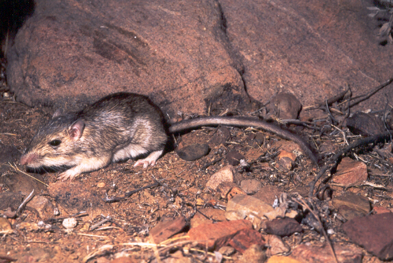

.  
(“Wikipedia Contributors. ‘Bailey’s Pocket Mouse.’ Wikipedia, the Free Encyclopedia. Wikipedia, the Free Encyclopedia, 30” 2018)

## 1.2 Hypothesis

Baileys Pocket Mouse is a native species to the study area and thus well adpated to the environment over the period studied. It represents a stable population for which we should see little change over time.

# 2 Methods

## 2.1 A Closer Look at Species Populations

1. This study used the data table `surveys.csv` from the Portals database. This table includes 30463 observations of the species *albigula, merriami, flavus, eremicus, spectabilis, penicillatus, hispidus, torridus, ordii, leucogaster, megalotis, maniculatus, fulvescens, baileyi*.
2. The downloaded csv file was imported into RStudio, analyzed, filtered, organized in a structured data table, and plotted as shown below.
3. The report was compiled in RStudio using RMarkdown, knitr, Pandoc, and a lot of luck!

```r
yearly_counts %>%
  datatable(rownames = FALSE,
            colnames = c("year", "species_id", "n"),
            class = "cell-border compact stripe",
            caption = htmltools::tags$caption("Table 1 - Species Populations in Analyzed Dataset", style="color:orange"),
            filter = list(position = "bottom"),
            extensions = 'Buttons', options = list(dom = 'Bfrtip',
            buttons = c('colvis', 'csv', 'pdf'))
  )
```

| year | species_id | n |
| --- | --- | --- |
| 1977 | DM | 181 |
| 1977 | DO | 12 |
| 1977 | DS | 29 |
| 1977 | OL | 1 |
| 1977 | PE | 2 |
| 1977 | PF | 22 |
| 1977 | PP | 3 |
| 1977 | RM | 2 |
| 1978 | DM | 336 |
| 1978 | DO | 21 |

[output cut: 282 more lines]

# 3 Results

We find that the population of Chaetodipus baileyi has dramatically increased during the study period. This may be due to a cheese factory moving into land adjacent to our sampling site in 1995 and ramping up production over the past two decades.

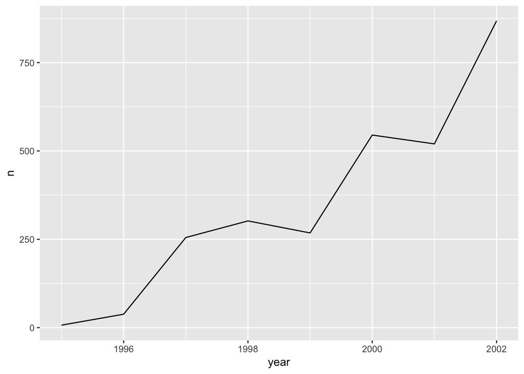

```r
ggplot(data = PB_data, mapping = aes(x=year, y=n)) + geom_line()
```

```r
#Jazz up this plot with a Title, a label for the y axis, and #change the line color to something of your choice
```

# Appendices

## 3.1 Acknowledgements: Key Resources used in the making of this Report

- bibtex citations stored in references.bib file | convert cites to bibtex using https://anystyle.io/
- Bootswatch themes | applied in yaml https://bootswatch.com
- *RMarkdown: The Definitive Guide* by Yihui Xie, J. J. Allaire, Garrett Grolemund | Free bookdown book at https://bookdown.org/yihui/rmarkdown/

# References

Ernest, Morgan, James Brown, Thomas Valone, and Ethan P. White. 2018. “Portal Project Teaching Database,” April. doi:10.6084/m9.figshare.1314459.v9.

“Wikipedia Contributors. ‘Bailey’s Pocket Mouse.’ Wikipedia, the Free Encyclopedia. Wikipedia, the Free Encyclopedia, 30.” 2018.